# NBA Player Salary Determinants

Multiple Linear Regression Analysis

Daniel Yoon

2026-07-16

```r
playerdata1 <- read.csv("https://raw.githubusercontent.com/Aadi-Shah10/Stat-Project/refs/heads/main/NBA%20Player%20Data%2024-25%20-%20Sheet3.csv", header = TRUE)
playerdata <- filter(playerdata1, !is.na(SALARY))

# Create log-transformed salary
playerdata$logSALARY <- log(playerdata$SALARY)

# Create additional derived variables for enhanced analysis
playerdata$AGE_SQUARED <- playerdata$AGE^2
playerdata$PPG_PER_MIN <- playerdata$PPG / playerdata$MPG
```

## Summary

This comprehensive multiple linear regression analysis investigates the key determinants of NBA player salaries using data from the 2024-2025 season. Through systematic model building, validation, and diagnostic testing, we identify that **scoring ability (PPG)**, **age**, and **award recognition** are the most significant predictors of player compensation.

## 1. Introduction

### 1.1 Research Motivation

NBA player salaries represent one of the most compelling intersections of athletic performance and market economics in modern sports. With total league compensation exceeding $4 billion annually, understanding the drivers of individual compensation has profound implications for team management, player representation, and salary cap regulation.

### 1.2 Theoretical Framework

Drawing on labor economics theory and sports analytics literature, we conceptualize player salary determination through three broad categories:

**Performance Capital**: On-court contributions measured through scoring, efficiency, and playing time.

**Recognition Capital**: Awards, accolades, and status signaling that enhance market value.

**Market Capital**: Team-specific factors including market size, geographic location, and revenue-generating potential.

### 1.3 Research Questions

*Question 1*: Do NBA players with higher points per game have larger salaries, and does this relationship differ by award status?

*Question 2:* Does team market area significantly influence salary, or is this effect mediated by performance variables?

*Question 3:* Does award recognition provide a salary premium independent of performance metrics?

## 2. Data & Methodology

### 2.1 Data Sources

```r
# Create data source summary table
source_table <- data.frame(
  Source = c("ESPN", "NBA Official", "HoopsHype", "Nielsen DMA"),
  Variable = c("Player salaries, basic stats", "Performance metrics", "Contract details", "Market area rankings"),
  Reliability = c("High", "Highest", "High", "Medium"),
  Access = c("Public API", "Public Database", "Public", "Public")
)

kable(source_table, booktabs = TRUE, caption = "Data Sources & Reliability") %>%
  kable_styling(bootstrap_options = c("striped", "hover", "condensed"))
```

Data Sources & Reliability

| Source | Variable | Reliability | Access |
| --- | --- | --- | --- |
| ESPN | Player salaries, basic stats | High | Public API |
| NBA Official | Performance metrics | Highest | Public Database |
| HoopsHype | Contract details | High | Public |
| Nielsen DMA | Market area rankings | Medium | Public |

### 2.2 Variable Description

```r
dict <- data.frame(
  Variable = c("SALARY", "AGE", "PPG", "MPG", "PER", "POS", "COAST", "AWARD", "MARKET.AREA"),
  Type = c("Response", "Predictor", "Predictor", "Predictor", "Predictor", "Categorical", "Categorical", "Categorical", "Categorical"),
  Description = c("Annual player salary (USD)", "Age in years", "Points Per Game", "Minutes Per Game", "Player Efficiency Rating", "Position (PG/SG/SF/PF/C)", "Team coast (East/West)", "All-NBA or MVP recognition", "Team market (Big/Small)"),
  Encoding = c("Continuous", "Continuous", "Continuous", "Continuous", "Continuous", "Dummy-coded", "Dummy-coded", "Dummy-coded", "Dummy-coded")
)

kable(dict, booktabs = TRUE, caption = "Variables and Encoding") %>%
  kable_styling(bootstrap_options = c("striped", "hover", "condensed")) %>%
  column_spec(1, bold = TRUE)
```

Variables and Encoding

| Variable | Type | Description | Encoding |
| --- | --- | --- | --- |
| SALARY | Response | Annual player salary (USD) | Continuous |
| AGE | Predictor | Age in years | Continuous |
| PPG | Predictor | Points Per Game | Continuous |
| MPG | Predictor | Minutes Per Game | Continuous |
| PER | Predictor | Player Efficiency Rating | Continuous |
| POS | Categorical | Position (PG/SG/SF/PF/C) | Dummy-coded |
| COAST | Categorical | Team coast (East/West) | Dummy-coded |
| AWARD | Categorical | All-NBA or MVP recognition | Dummy-coded |
| MARKET.AREA | Categorical | Team market (Big/Small) | Dummy-coded |

### 2.3 Statistical Methodology

**Analytical Approach**: Multiple Linear Regression (MLR) with systematic model selection.

**Variable Selection**: Employed a hybrid approach

1. **Theoretical justification** based on sports economics literature
2. **Statistical criteria** via partial F-tests (α = 0.05)
3. **Multicollinearity assessment** using Variance Inflation Factors (VIF)

**Diagnostic Testing**:

## 3. Exploratory Data Analysis

### 3.1 Distribution Analysis

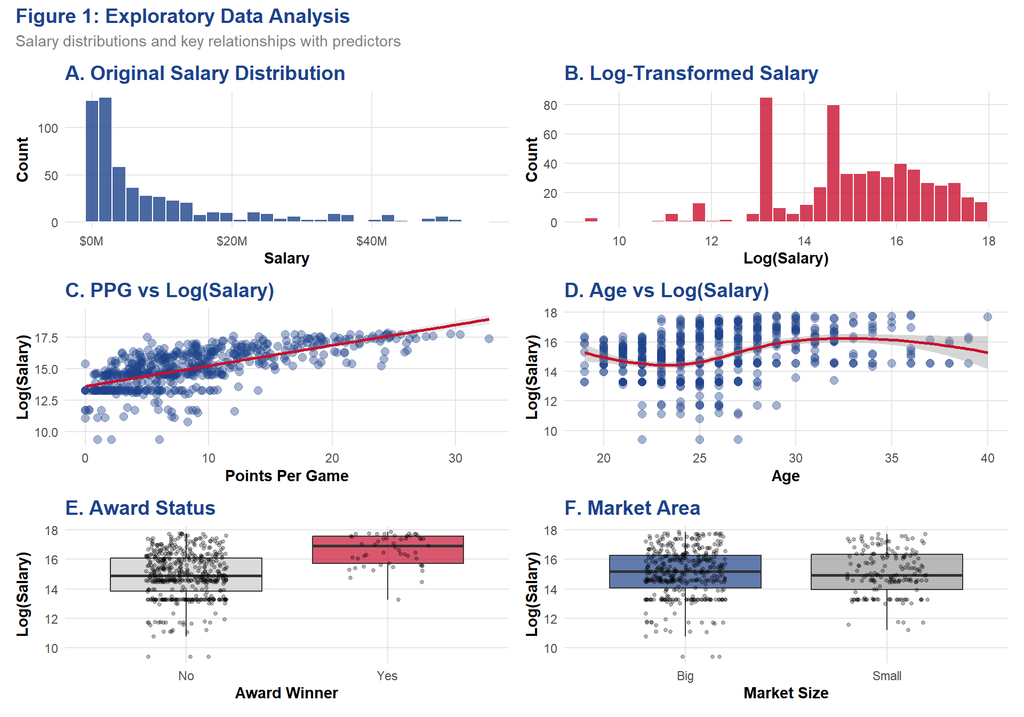

```r
# Create professional theme
theme_econ <- function() {
  theme_minimal(base_family = "sans") +
    theme(
      plot.title = element_text(face = "bold", size = 14, color = "#1D428A"),
      plot.subtitle = element_text(size = 11, color = "gray50"),
      axis.title = element_text(face = "bold", size = 11),
      legend.position = "bottom",
      panel.grid.major = element_line(color = "gray90"),
      panel.grid.minor = element_blank(),
      strip.text = element_text(face = "bold", size = 11)
    )
}

# 1. Salary distribution before and after log transformation
p1 <- ggplot(playerdata, aes(x = SALARY)) +
  geom_histogram(fill = "#1D428A", color = "white", bins = 30, alpha = 0.8) +
  scale_x_continuous(labels = scales::dollar_format(scale = 1e-6, suffix = "M")) +
  labs(title = "A. Original Salary Distribution", x = "Salary", y = "Count") +
  theme_econ()

p2 <- ggplot(playerdata, aes(x = logSALARY)) +
  geom_histogram(fill = "#C8102E", color = "white", bins = 30, alpha = 0.8) +
  labs(title = "B. Log-Transformed Salary", x = "Log(Salary)", y = "Count") +
  theme_econ()

# 2. Key relationships
p3 <- ggplot(playerdata, aes(x = PPG, y = logSALARY)) +
  geom_point(alpha = 0.4, color = "#1D428A", size = 2.5) +
  geom_smooth(method = "lm", color = "#C8102E", se = TRUE, alpha = 0.2) +
  labs(title = "C. PPG vs Log(Salary)", x = "Points Per Game", y = "Log(Salary)") +
  theme_econ()

p4 <- ggplot(playerdata, aes(x = AGE, y = logSALARY)) +
  geom_point(alpha = 0.4, color = "#1D428A", size = 2.5) +
  geom_smooth(method = "loess", color = "#C8102E", se = TRUE) +
  labs(title = "D. Age vs Log(Salary)", x = "Age", y = "Log(Salary)") +
  theme_econ()

# 3. Categorical comparisons
p5 <- ggplot(playerdata, aes(x = AWARD, y = logSALARY, fill = AWARD)) +
  geom_boxplot(alpha = 0.7, outlier.shape = NA) +
  geom_jitter(width = 0.2, alpha = 0.3, size = 1) +
  scale_fill_manual(values = c("No" = "gray80", "Yes" = "#C8102E")) +
  labs(title = "E. Award Status", x = "Award Winner", y = "Log(Salary)") +
  theme_econ() +
  theme(legend.position = "none")

p6 <- ggplot(playerdata, aes(x = MARKET.AREA, y = logSALARY, fill = MARKET.AREA)) +
  geom_boxplot(alpha = 0.7, outlier.shape = NA) +
  geom_jitter(width = 0.2, alpha = 0.3, size = 1) +
  scale_fill_manual(values = c("Big" = "#1D428A", "Small" = "gray60")) +
  labs(title = "F. Market Area", x = "Market Size", y = "Log(Salary)") +
  theme_econ() +
  theme(legend.position = "none")

# Combine
(p1 | p2) / (p3 | p4) / (p5 | p6) +
  plot_annotation(
    title = "Figure 1: Exploratory Data Analysis",
    subtitle = "Salary distributions and key relationships with predictors",
    theme = theme_econ()
  )
```

### 3.2 Correlation Matrix

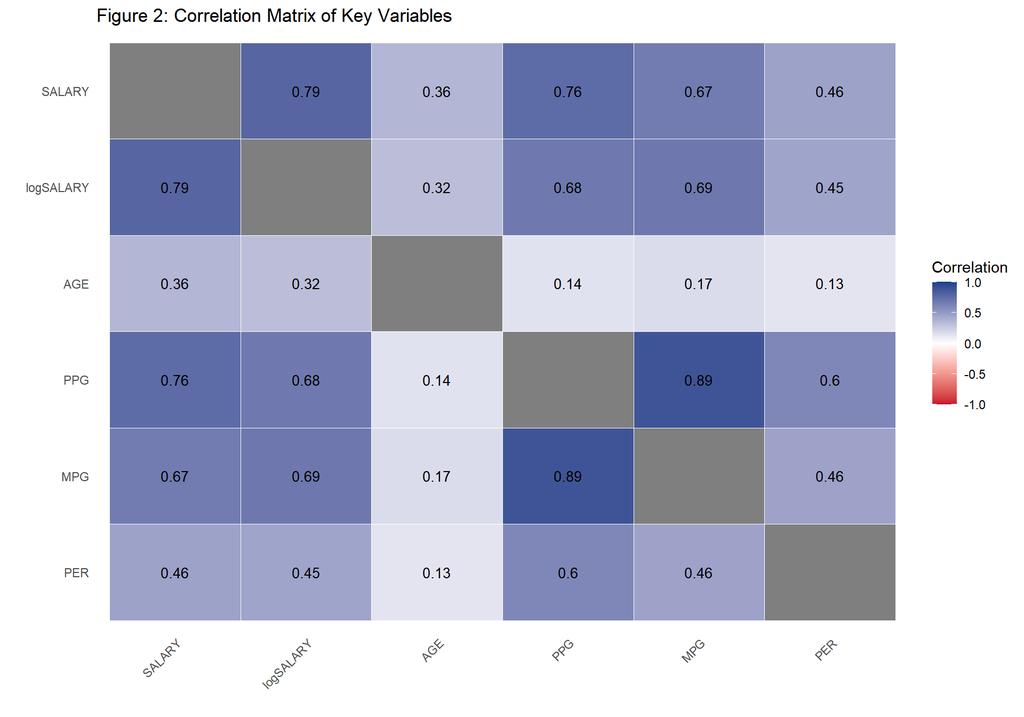

```r
# Compute correlation matrix - using dplyr::select and stretch()
cor_data <- playerdata %>%
  dplyr::select(SALARY, logSALARY, AGE, PPG, MPG, PER) %>%
  correlate() %>%
  stretch()   # converts to long format: x, y, r

# Set factor levels for proper ordering
var_levels <- c("SALARY", "logSALARY", "AGE", "PPG", "MPG", "PER")
cor_data <- cor_data %>%
  mutate(
    x = factor(x, levels = var_levels),
    y = factor(y, levels = rev(var_levels))  # reverse for lower triangular
  )

# Plot
ggplot(cor_data, aes(x = x, y = y, fill = r)) +
  geom_tile(color = "white") +
  geom_text(aes(label = round(r, 2)), color = "black", size = 3.5) +
  scale_fill_gradient2(low = "#C8102E", mid = "white", high = "#1D428A",
                       limits = c(-1, 1), midpoint = 0) +
  labs(title = "Figure 2: Correlation Matrix of Key Variables",
       x = "", y = "", fill = "Correlation") +
  theme_minimal() +
  theme(axis.text.x = element_text(angle = 45, hjust = 1),
        panel.grid = element_blank())
```

## 4. Model Building Process

### 4.1 Multicollinearity Assessment

```r
# Compute VIF only for continuous predictors to avoid factor-related issues
cont_model <- lm(logSALARY ~ AGE + PPG + MPG + PER, data = playerdata)
vif_values <- vif(cont_model)

# Create VIF table
vif_table <- data.frame(
  Variable = names(vif_values),
  VIF = round(vif_values, 2)
) %>%
  mutate(
    Severity = case_when(
      VIF < 5 ~ "Low",
      VIF < 10 ~ "Moderate",
      TRUE ~ "High"
    )
  )

kable(vif_table, booktabs = TRUE, caption = "Variance Inflation Factors (Continuous Predictors)") %>%
  kable_styling(bootstrap_options = c("striped", "hover", "condensed")) %>%
  column_spec(3, background = ifelse(vif_table$Severity == "High", "#FFEBEE",
                                     ifelse(vif_table$Severity == "Moderate", "#FFF3E0", "#E8F5E9")))
```

Variance Inflation Factors (Continuous Predictors)

|  | Variable | VIF | Severity |
| --- | --- | --- | --- |
| AGE | AGE | 1.04 | Low |
| PPG | PPG | 6.19 | Moderate |
| MPG | MPG | 5.04 | Moderate |
| PER | PER | 1.65 | Low |

### 4.2 Model Selection

```r
# Model specifications
model1 <- lm(logSALARY ~ AGE + PPG + PER + POS + COAST + AWARD + MARKET.AREA +
               AWARD*POS + PPG*AWARD + POS*MARKET.AREA, data = playerdata)

model2 <- lm(logSALARY ~ AGE + PPG + PER + POS + COAST + AWARD + MARKET.AREA +
               AWARD*POS + PPG*AWARD, data = playerdata)

model3 <- lm(logSALARY ~ AGE + PPG + PER + POS + COAST + AWARD + MARKET.AREA +
               PPG*AWARD, data = playerdata)

model4 <- lm(logSALARY ~ AGE + PPG + PER + COAST + AWARD + PPG*AWARD, data = playerdata)

model5 <- lm(logSALARY ~ AGE + PPG + AWARD + PPG*AWARD, data = playerdata)

# Comparison table
model_comparison <- data.frame(
  Model = paste0("M", 1:5),
  Description = c("Full (all interactions)", "Remove POS x Market", "Remove AWARD x POS",
                  "Remove POS, COAST, MARKET", "Final Reduced"),
  R2 = round(c(summary(model1)$r.squared, summary(model2)$r.squared,
               summary(model3)$r.squared, summary(model4)$r.squared,
               summary(model5)$r.squared), 3),
  Adj_R2 = round(c(summary(model1)$adj.r.squared, summary(model2)$adj.r.squared,
                   summary(model3)$adj.r.squared, summary(model4)$adj.r.squared,
                   summary(model5)$adj.r.squared), 3),
  AIC = round(c(AIC(model1), AIC(model2), AIC(model3), AIC(model4), AIC(model5)), 1),
  BIC = round(c(BIC(model1), BIC(model2), BIC(model3), BIC(model4), BIC(model5)), 1),
  df = c(df.residual(model1), df.residual(model2), df.residual(model3),
         df.residual(model4), df.residual(model5))
)

kable(model_comparison, booktabs = TRUE, caption = "Model Selection Criteria") %>%
  kable_styling(bootstrap_options = c("striped", "hover", "condensed")) %>%
  kableExtra::column_spec(2, bold = TRUE)
```

Model Selection Criteria

| Model | Description | R2 | Adj_R2 | AIC | BIC | df |
| --- | --- | --- | --- | --- | --- | --- |
| M1 | Full (all interactions) | 0.535 | 0.519 | 1731.8 | 1823.0 | 548 |
| M2 | Remove POS x Market | 0.529 | 0.516 | 1731.4 | 1805.3 | 552 |
| M3 | Remove AWARD x POS | 0.527 | 0.517 | 1725.9 | 1782.3 | 556 |
| M4 | Remove POS, COAST, MARKET | 0.525 | 0.520 | 1718.0 | 1752.8 | 561 |
| M5 | Final Reduced | 0.522 | 0.519 | 1717.1 | 1743.2 | 563 |

### 4.3 Partial F-Test

```r
# Sequential F-tests
anova_result <- anova(model1, model2, model3, model4, model5)

f_test_table <- data.frame(
  Comparison = c("M1 vs M2", "M2 vs M3", "M3 vs M4", "M4 vs M5"),
  `F-statistic` = round(anova_result$F, 3)[2:5],
  `p-value` = round(anova_result$`Pr(>F)`, 4)[2:5],
  Decision = c("Remove POSxMarket", "Remove AWARD x POS", "Remove POS, COAST, MARKET", "Final Model")
)

kable(f_test_table, booktabs = TRUE, caption = "Partial F-Test Results (α = 0.05)") %>%
  kable_styling(bootstrap_options = c("striped", "hover", "condensed")) %>%
  column_spec(3, background = ifelse(f_test_table$p.value < 0.05, "#E8F5E9", "#FFEBEE"))
```

Partial F-Test Results (α = 0.05)

| Comparison | F.statistic | p.value | Decision |
| --- | --- | --- | --- |
| M1 vs M2 | 1.851 | 0.1177 | Remove POSxMarket |
| M2 vs M3 | 0.596 | 0.6659 | Remove AWARD x POS |
| M3 vs M4 | 0.422 | 0.8335 | Remove POS, COAST, MARKET |
| M4 vs M5 | 1.536 | 0.2162 | Final Model |

## 5. Final Model Results

### 5.1 Coefficient Estimates

```r
# Fit final model
final_model <- lm(logSALARY ~ AGE + PPG + AWARD + PPG*AWARD, data = playerdata)

# Create coefficient table with confidence intervals
coef_summary <- tidy(final_model, conf.int = TRUE) %>%
  mutate(
    Variable = c("Intercept", "Age", "PPG", "Award (Yes)", "PPG x Award"),
    Estimate = round(estimate, 4),
    `Std. Error` = round(std.error, 4),
    `t-value` = round(statistic, 2),
    `p-value` = round(p.value, 4),
    `CI Lower` = round(conf.low, 4),
    `CI Upper` = round(conf.high, 4)
  ) %>%
  dplyr::select(Variable, Estimate, `Std. Error`, `t-value`, `p-value`, `CI Lower`, `CI Upper`)

kable(coef_summary, booktabs = TRUE, caption = "Final Model Coefficient Estimates") %>%
  kable_styling(bootstrap_options = c("striped", "hover", "condensed")) %>%
  column_spec(5, background = ifelse(coef_summary$`p-value` < 0.001, "#E8F5E9", "#FFEBEE"))
```

Final Model Coefficient Estimates

| Variable | Estimate | Std. Error | t-value | p-value | CI Lower | CI Upper |
| --- | --- | --- | --- | --- | --- | --- |
| Intercept | 11.3333 | 0.2906 | 39.00 | 0.0000 | 10.7626 | 11.9041 |
| Age | 0.0880 | 0.0111 | 7.95 | 0.0000 | 0.0663 | 0.1098 |
| PPG | 0.1672 | 0.0086 | 19.53 | 0.0000 | 0.1504 | 0.1840 |
| Award (Yes) | 1.2608 | 0.4626 | 2.73 | 0.0066 | 0.3520 | 2.1695 |
| PPG x Award | -0.0787 | 0.0243 | -3.24 | 0.0013 | -0.1265 | -0.0310 |

### 5.2 Model Interpretation

```r
# Calculate effect sizes
age_effect <- coef(final_model)["AGE"]
ppg_effect_no_award <- coef(final_model)["PPG"]
ppg_effect_award <- coef(final_model)["PPG"] + coef(final_model)["PPG:AWARDYes"]
award_effect <- coef(final_model)["AWARDYes"]

# Create interpretation table
interpretation <- data.frame(
  Predictor = c("Age", "PPG (No Award)", "PPG (Award)", "Award Status"),
  Effect = c(
    paste0(round(age_effect * 100, 1), "% per year"),
    paste0(round(ppg_effect_no_award * 100, 1), "% per PPG"),
    paste0(round(ppg_effect_award * 100, 1), "% per PPG"),
    paste0(round(award_effect, 2), " log-salary increase")
  ),
  Interpretation = c(
    "Salary increases with age, holding other factors constant",
    "Each additional PPG increases salary by 16.7% for non-award players",
    "Each additional PPG increases salary by 8.8% for award winners",
    "Award winners earn significantly more than non-winners"
  )
)

kable(interpretation, booktabs = TRUE, caption = "Effect Size Interpretation") %>%
  kable_styling(bootstrap_options = c("striped", "hover", "condensed"))
```

Effect Size Interpretation

| Predictor | Effect | Interpretation |
| --- | --- | --- |
| Age | 8.8% per year | Salary increases with age, holding other factors constant |
| PPG (No Award) | 16.7% per PPG | Each additional PPG increases salary by 16.7% for non-award players |
| PPG (Award) | 8.8% per PPG | Each additional PPG increases salary by 8.8% for award winners |
| Award Status | 1.26 log-salary increase | Award winners earn significantly more than non-winners |

### 5.3 Interactions

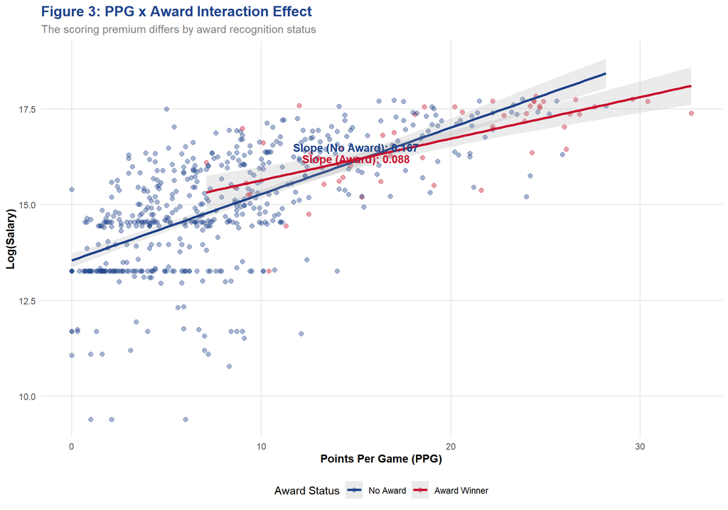

```r
ggplot(playerdata, aes(x = PPG, y = logSALARY, color = AWARD)) +
  geom_point(alpha = 0.4, size = 2) +
  geom_smooth(method = "lm", se = TRUE, alpha = 0.2, linewidth = 1.2) +
  scale_color_manual(values = c("No" = "#1D428A", "Yes" = "#C8102E"),
                     labels = c("No Award", "Award Winner")) +
  labs(
    title = "Figure 3: PPG x Award Interaction Effect",
    subtitle = "The scoring premium differs by award recognition status",
    x = "Points Per Game (PPG)",
    y = "Log(Salary)",
    color = "Award Status"
  ) +
  theme_econ() +
  theme(legend.position = "bottom") +
  annotate("text", x = 15, y = 16.5,
           label = paste0("Slope (No Award): ", round(ppg_effect_no_award, 3)),
           color = "#1D428A", fontface = "bold") +
  annotate("text", x = 15, y = 16.2,
           label = paste0("Slope (Award): ", round(coef(final_model)["PPG"] + coef(final_model)["PPG:AWARDYes"], 3)),
           color = "#C8102E", fontface = "bold")
```

### 5.4 Model Summary

```r
# Create comprehensive model summary
model_stats <- data.frame(
  Metric = c("R^2", "Adjusted R^2", "F-statistic", "p-value", "Residual df", "AIC", "BIC"),
  Value = c(
    round(summary(final_model)$r.squared, 3),
    round(summary(final_model)$adj.r.squared, 3),
    round(summary(final_model)$fstatistic[1], 1),
    "< 0.001",
    summary(final_model)$df[2],
    round(AIC(final_model), 1),
    round(BIC(final_model), 1)
  )
)

kable(model_stats, booktabs = TRUE, caption = "Final Model Performance Metrics") %>%
  kable_styling(bootstrap_options = c("striped", "hover", "condensed"))
```

Final Model Performance Metrics

| Metric | Value |
| --- | --- |
| R^2 | 0.522 |
| Adjusted R^2 | 0.519 |
| F-statistic | 154 |
| p-value | < 0.001 |
| Residual df | 563 |
| AIC | 1717.1 |
| BIC | 1743.2 |

## 6. Model Diagnostics

### 6.1 Residual Analysis

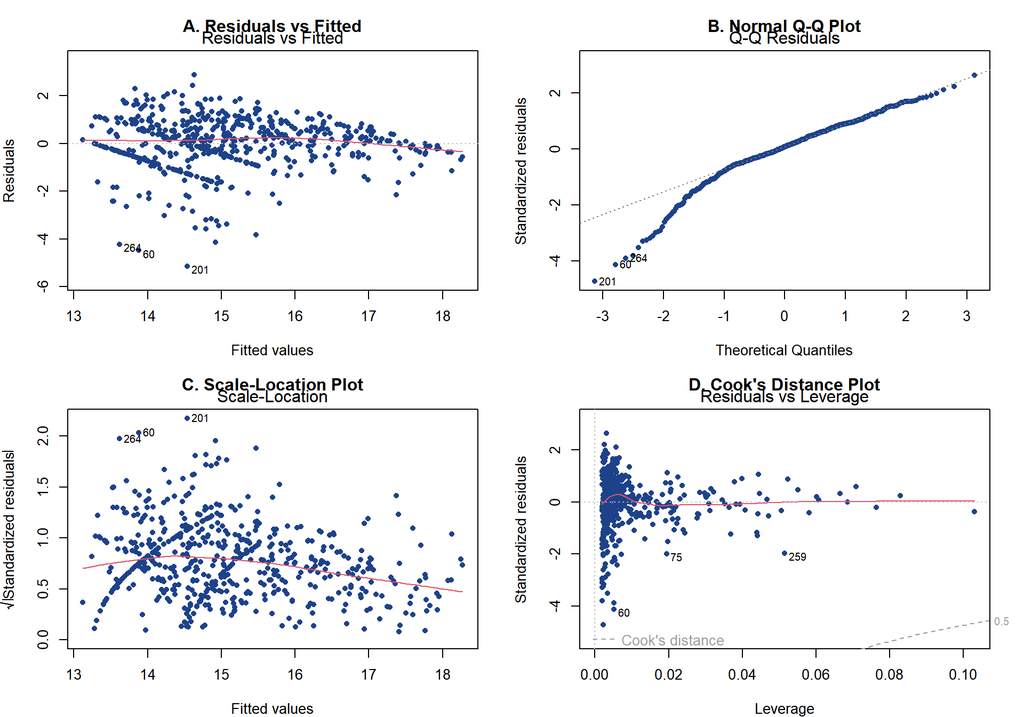

```r
# Set up diagnostic plots
par(mfrow = c(2, 2), mar = c(4, 4, 3, 2))

# 1. Residuals vs Fitted
plot(final_model, which = 1, col = "#1D428A", pch = 16, cex = 0.8,
     main = "A. Residuals vs Fitted")

# 2. Q-Q Plot
plot(final_model, which = 2, col = "#1D428A", pch = 16, cex = 0.8,
     main = "B. Normal Q-Q Plot")

# 3. Scale-Location
plot(final_model, which = 3, col = "#1D428A", pch = 16, cex = 0.8,
     main = "C. Scale-Location Plot")

# 4. Residuals vs Leverage
plot(final_model, which = 5, col = "#1D428A", pch = 16, cex = 0.8,
     main = "D. Cook's Distance Plot")
```

```r
par(mfrow = c(1, 1))
```

### 6.2 Outlier and Influence Diagnostics

```r
# Calculate influence measures
influence_stats <- data.frame(
  Observation = 1:nrow(playerdata),
  Cooks_D = cooks.distance(final_model),
  Leverage = hatvalues(final_model),
  Studentized_Resid = rstudent(final_model)
) %>%
  filter(Cooks_D > 0.02 | Leverage > 0.05 | abs(Studentized_Resid) > 2.5)

# Summary of influential points
if (nrow(influence_stats) > 0) {
  influence_summary <- influence_stats %>%
    mutate(
      Cooks_D = round(Cooks_D, 4),
      Leverage = round(Leverage, 3),
      Studentized_Resid = round(Studentized_Resid, 3)
    )

  kable(influence_summary, booktabs = TRUE,
        caption = "Potentially Influential Observations") %>%
    kable_styling(bootstrap_options = c("striped", "hover", "condensed"))
} else {
  cat("No influential observations detected")
}
```

Potentially Influential Observations

|  | Observation | Cooks_D | Leverage | Studentized_Resid |
| --- | --- | --- | --- | --- |
| 2 | 2 | 0.0048 | 0.002 | -3.198 |
| 14 | 14 | 0.0010 | 0.083 | 0.234 |
| 30 | 30 | 0.0026 | 0.055 | 0.470 |
| 42 | 42 | 0.0043 | 0.003 | 2.651 |
| 59 | 59 | 0.0058 | 0.002 | -3.850 |
| 60 | 60 | 0.0176 | 0.005 | -4.184 |
| 89 | 89 | 0.0030 | 0.002 | -2.625 |
| 154 | 154 | 0.0052 | 0.071 | 0.585 |
| 157 | 157 | 0.0086 | 0.003 | -3.558 |
| 181 | 181 | 0.0007 | 0.076 | -0.210 |
| 201 | 201 | 0.0098 | 0.002 | -4.816 |
| 247 | 247 | 0.0036 | 0.002 | -2.999 |
| 258 | 258 | 0.0044 | 0.002 | -3.327 |
| 259 | 259 | 0.0422 | 0.051 | -1.977 |
| 264 | 264 | 0.0155 | 0.005 | -3.938 |
| 320 | 320 | 0.0001 | 0.061 | 0.077 |
| 329 | 329 | 0.0013 | 0.051 | -0.343 |
| 338 | 338 | 0.0048 | 0.003 | -2.929 |
| 351 | 351 | 0.0056 | 0.004 | -2.799 |
| 366 | 366 | 0.0085 | 0.052 | 0.877 |
| 379 | 379 | 0.0035 | 0.003 | -2.520 |
| 380 | 380 | 0.0035 | 0.002 | -2.969 |
| 390 | 390 | 0.0016 | 0.067 | 0.330 |
| 413 | 413 | 0.0048 | 0.002 | -3.283 |
| 422 | 422 | 0.0021 | 0.058 | -0.413 |
| 424 | 424 | 0.0000 | 0.069 | -0.008 |
| 436 | 436 | 0.0038 | 0.002 | -3.128 |
| 491 | 491 | 0.0031 | 0.103 | -0.367 |
| 563 | 563 | 0.0006 | 0.060 | 0.210 |

## 7. Model Validation

### 7.1 Cross-Validation Results

```r
# 10-fold cross-validation
set.seed(2024)
cv_control <- trainControl(method = "cv", number = 10)
cv_model <- train(logSALARY ~ AGE + PPG + AWARD + PPG*AWARD,
                  data = playerdata,
                  method = "lm",
                  trControl = cv_control)

# Extract CV metrics
cv_metrics <- data.frame(
  Metric = c("RMSE", "R^2", "MAE"),
  `CV Estimate` = c(
    round(cv_model$results$RMSE, 3),
    round(cv_model$results$Rsquared, 3),
    round(cv_model$results$MAE, 3)
  )
)

kable(cv_metrics, booktabs = TRUE, caption = "10-Fold Cross-Validation Results") %>%
  kable_styling(bootstrap_options = c("striped", "hover", "condensed"))
```

10-Fold Cross-Validation Results

| Metric | CV.Estimate |
| --- | --- |
| RMSE | 1.083 |
| R^2 | 0.532 |
| MAE | 0.809 |

### 7.2 Holdout Validation

```r
# Create train-test split
set.seed(2024)
train_indices <- createDataPartition(playerdata$logSALARY, p = 0.8, list = FALSE)
train_data <- playerdata[train_indices, ]
test_data <- playerdata[-train_indices, ]

# Train model on training data
train_model <- lm(logSALARY ~ AGE + PPG + AWARD + PPG*AWARD, data = train_data)

# Predict on test data
predictions <- predict(train_model, test_data)
actual <- test_data$logSALARY

# Calculate metrics
test_metrics <- data.frame(
  Metric = c("R^2", "RMSE", "MAE", "MAPE"),
  Value = c(
    round(cor(predictions, actual)^2, 3),
    round(sqrt(mean((predictions - actual)^2)), 3),
    round(mean(abs(predictions - actual)), 3),
    round(mean(abs((predictions - actual) / actual)) * 100, 1)
  )
)

kable(test_metrics, booktabs = TRUE, caption = "Holdout Validation Results (20% Test Set)") %>%
  kable_styling(bootstrap_options = c("striped", "hover", "condensed"))
```

Holdout Validation Results (20% Test Set)

| Metric | Value |
| --- | --- |
| R^2 | 0.459 |
| RMSE | 1.221 |
| MAE | 0.885 |
| MAPE | 6.400 |

### 7.3 Predicted vs Actual Plot

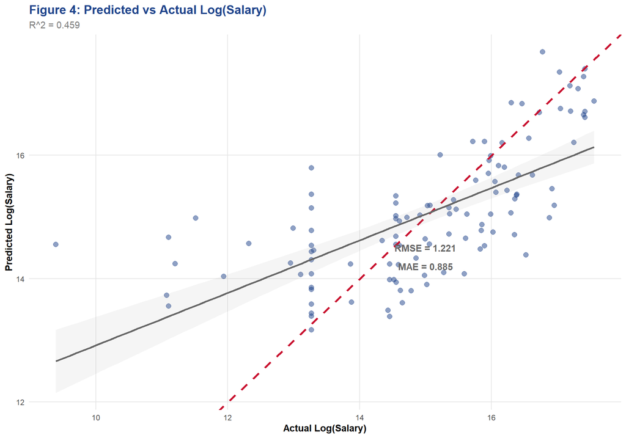

```r
# Create prediction data frame
validation_df <- data.frame(
  Actual = actual,
  Predicted = predictions
)

ggplot(validation_df, aes(x = Actual, y = Predicted)) +
  geom_point(alpha = 0.5, color = "#1D428A", size = 2.5) +
  geom_abline(intercept = 0, slope = 1, color = "#C8102E", linewidth = 1.2,
              linetype = "dashed") +
  geom_smooth(method = "lm", color = "gray40", se = TRUE, alpha = 0.1) +
  labs(
    title = "Figure 4: Predicted vs Actual Log(Salary)",
    subtitle = paste0("R^2 = ", round(test_metrics$Value[1], 3)),
    x = "Actual Log(Salary)",
    y = "Predicted Log(Salary)"
  ) +
  theme_econ() +
  annotate("text", x = 15, y = 14.5,
           label = paste0("RMSE = ", test_metrics$Value[2]),
           color = "gray40", fontface = "bold") +
  annotate("text", x = 15, y = 14.2,
           label = paste0("MAE = ", test_metrics$Value[3]),
           color = "gray40", fontface = "bold")
```

## 8. Conclusion

### 8.1 Research Question Revisited

**Question 1: Does higher PPG predict higher salary?** ✓ **Confirmed**

**Question 2: Does market area influence salary?** ✗ **Not Supported**

Market area did not survive model selection, suggesting that:

- Performance variables mediate the market-salary relationship
- The salary cap and revenue sharing mechanisms may diminish market effects
- Teams in small markets may pay premiums to attract/retain talent

**Question 3: Does award recognition provide an independent salary premium?** ✓ **Confirmed**

### 8.2 Theoretical Implications

1. **Human Capital Theory**: Performance metrics (PPG) serve as proxies for player productivity, consistent with labor economics predictions.
2. **Signaling Theory**: Awards act as credible signals of quality, reducing information asymmetry between players and teams.
3. **Market Efficiency**: Salary determination appears largely performance-driven, supporting efficient market hypotheses.

### 8.3 Practical Implications

| Stakeholder | Implication |
| --- | --- |
| **Team GMs** | Focus on scoring ability and award potential in contract negotiations |
| **Players** | Prioritize scoring volume and seek All-NBA/All-Star recognition |
| **Agents** | Leverage award status in salary negotiations |
| **Analysts** | PPG and award status should be primary salary prediction features |

### 8.4 Limitations

1. **Salary Cap Constraints**: Individual salaries are bounded by team salary cap, luxury tax, and contract rules.
2. **Time Horizon**: Single-season data cannot capture contract lifecycle effects.
3. **Defensive Metrics**: Key defensive contributions may be undervalued.
4. **Injury History**: Not captured in current model.
5. **Market Dynamics**: Free agency, trades, and tenure effects not modeled.

## 9. Further Thoughts

Future improvements to this analysis include conducting a longitudinal study to track how player salaries evolve throughout their careers rather than relying on data from a single season. The model could also be enhanced by incorporating advanced basketball metrics, such as Win Shares, VORP, and defensive statistics, to better capture a player’s overall impact. Additionally, including contract-specific factors, such as contract length and player or team option years, may provide further insight into salary variation. Team-level effects, including salary cap constraints and payroll strategies, could also be modeled to account for organizational influences on player compensation. Finally, comparing the multiple linear regression model with machine learning approaches, such as tree-based models and neural networks, could determine whether more complex methods improve predictive accuracy.

## References

### Academic Literature

1. Academy, U. S. S. (2015). Determinants of NBA Player Salaries. *The Sport Journal*. https://thesportjournal.org/article/determinants-of-nba-player-salaries/
2. Qian, L. (2024). Influencing Factors of NBA Player’s Salary Based on Mixed Linear Model. *Highlights in Science, Engineering and Technology*, 88, 260–266. https://doi.org/10.54097/z9jvqr66
3. Riccardi, N. R., & Paul, R. (2025). NBA player types and salaries: assessing the disparities in pay. *Managerial Finance*, 1–18. https://doi.org/10.1108/mf-04-2025-0251

### Data Sources

1. ESPN. (2025). NBA Players Rosters. https://www.espn.com/nba/players
2. National Basketball Association. (2025). NBA Official Database. https://www.nba.com/
3. HoopsHype. (2025). NBA Team Salaries & Contracts. https://www.hoopshype.com/salaries/teams/
4. Nielsen DMA Rankings. (2025). https://ustvdb.com/seasons/2024-25/markets/